# **Final Submission**

## **Problem Definition**

**The context:** Why is this problem important to solve?

Malaria is a deadly disease that is trasmitted by infected mosquitos in predominatly warmer regions of the planet

Malaria is the leading cause of death in many countries with over 95% of case and 96% of deaths occurring in Afria

**The objectives:** What is the intended goal?

To Create a Machine Vision Model to detect malaria from the image of a patient's red blood cells

**The key questions:** What are the key questions that need to be answered?

What is the best model format to use in a real world exxample

**The problem formulation:** What is it that we are trying to solve using data science?

We are trying to lower the cost and speed of malaria detection

## **Data Description**

There are a total of 24,958 train and 2,600 test images (colored) that we have taken from microscopic images. These images are of the following categories:

**Parasitized:** The parasitized cells contain the Plasmodium parasite which causes malaria  
**Uninfected:** The uninfected cells are free of the Plasmodium parasites

### **Creating the GPU session for faster processing times**

```python
gpu_info = !nvidia-smi
gpu_info = '\n'.join(gpu_info)
if gpu_info.find('failed') >= 0:
  print('Not connected to a GPU')
else:
  print(gpu_info)
```

```
Wed Jun  8 02:10:27 2022
+-----------------------------------------------------------------------------+
| NVIDIA-SMI 460.32.03    Driver Version: 460.32.03    CUDA Version: 11.2     |
|-------------------------------+----------------------+----------------------+
| GPU  Name        Persistence-M| Bus-Id        Disp.A | Volatile Uncorr. ECC |
| Fan  Temp  Perf  Pwr:Usage/Cap|         Memory-Usage | GPU-Util  Compute M. |
|                               |                      |               MIG M. |
|===============================+======================+======================|
|   0  Tesla T4            Off  | 00000000:00:04.0 Off |                    0 |
| N/A   69C    P8    12W /  70W |      0MiB / 15109MiB |      0%      Default |
|                               |                      |                  N/A |
+-------------------------------+----------------------+----------------------+

+-----------------------------------------------------------------------------+
| Processes:                                                                  |
|  GPU   GI   CI        PID   Type   Process name                  GPU Memory |
|        ID   ID                                                   Usage      |
|=============================================================================|
|  No running processes found                                                 |
+-----------------------------------------------------------------------------+
```

### **Mounting the Drive**

```python
#Mounting the drive
from google.colab import drive
drive.mount('/content/drive')
```

### **Loading libraries**

```python
import zipfile
import os
os.environ['PYTHONHASHSEED']=str(42)
from PIL import Image
import numpy as np
import pandas as pd
import matplotlib.pyplot as plt
import seaborn as sns
import collections, numpy
import random
import tensorflow as tf
import cv2



from sklearn.model_selection import train_test_split
from sklearn.preprocessing import MinMaxScaler
from sklearn.metrics import classification_report
from sklearn.metrics import confusion_matrix



from tensorflow.keras.models import Sequential
from tensorflow.keras.layers import Dense, Conv2D, MaxPooling2D, MaxPool2D, BatchNormalization, Dropout, Flatten, LeakyReLU, GlobalAvgPool2D, Activation
from tensorflow.keras.utils import to_categorical
from tensorflow.keras import optimizers
from tensorflow.keras import backend
from tensorflow.keras.utils import to_categorical
from tensorflow.keras.callbacks import EarlyStopping, ModelCheckpoint
from tensorflow.keras.preprocessing.image import ImageDataGenerator
from tensorflow.keras.applications.vgg16 import VGG16
from tensorflow.keras import Model

from keras.utils.vis_utils import plot_model
from keras.regularizers import l2
from keras.layers import LSTM


#to ignore warnings
import warnings
warnings.filterwarnings('ignore')

# Remove the limit from the number of displayed columns and rows. It helps to see the entire dataframe while printing it
pd.set_option("display.max_columns", None)
pd.set_option("display.max_rows", 200)
```

```python
def reset_random_seeds():
   os.environ['PYTHONHASHSEED']=str(42)
   tf.random.set_seed(42)
   np.random.seed(42)
   random.seed(42)
   backend.clear_session()
```

### **Let us load the data**

```python
#Storing the path of the data file from the Google drive
path = '/content/cell_images.zip'

#The data is provided as a zip file so we need to extract the files from the zip file
with zipfile.ZipFile(path, 'r') as zip_ref:
    zip_ref.extractall()
```

The extracted folder has different folders for train and test data which further contains the different sizes of images for parasitized and uninfected cells within the respective folder name.

The size of all images must be the same and should be converted to 4D arrays so that they can be used as an input for the convolutional neural network. Also, we need to create the labels for both types of images to be able to train and test the model.

Let's do the same for the training data first and then we will use the same code for the test data as well.

Setting a small image size will improve computing time, but larger size images will be tested to see if it improves model performance

```python
# Loading the training and testing set folders

train_dir = '/content/cell_images/train'
test_dir = '/content/cell_images/test'

# Set image size

SIZE = 64

# Create arrays to store images and labels

train_images = []
train_labels = []

test_images = []
test_labels = []
```

```python
#We will run the same code for "parasitized" as well as "uninfected" folders within the "train" folder
for folder_name in ['/parasitized/', '/uninfected/']:

    #Path of the folder
    images_path = os.listdir(train_dir + folder_name)

    for i, image_name in enumerate(images_path):
        try:
            #Opening each image using the path of that image
            image = Image.open(train_dir + folder_name + image_name)

            #Resizing each image to (64,64)
            image = image.resize((SIZE, SIZE))

            #Converting images to arrays and appending that array to the empty list defined above
            train_images.append(np.array(image))

            #Creating labels for parasitized and uninfected images
            if folder_name=='/parasitized/':
                train_labels.append(1)
            else:
                train_labels.append(0)
        except Exception:
            pass

#Converting lists to arrays
train_images = np.array(train_images)
train_labels = np.array(train_labels)
```

```python
#We will run the same code for "parasitized" as well as "uninfected" folders within the "test" folder
for folder_name in ['/parasitized/', '/uninfected/']:

    #Path of the folder
    images_path = os.listdir(test_dir + folder_name)

    for i, image_name in enumerate(images_path):
        try:
            #Opening each image using the path of that image
            image = Image.open(test_dir + folder_name + image_name)

            #Resizing each image to (64,64)
            image = image.resize((SIZE, SIZE))

            #Converting images to arrays and appending that array to the empty list defined above
            test_images.append(np.array(image))

            #Creating labels for parasitized and uninfected images
            if folder_name=='/parasitized/':
                test_labels.append(1)
            else:
                test_labels.append(0)
        except Exception:
            pass

#Converting lists to arrays
test_images = np.array(test_images)
test_labels = np.array(test_labels)
```

### **Checking the shape of train and test images**

```python
# shape of images

print ("Train Image shape:", train_images.shape)
print("Test image shape:", test_images.shape)
```

```
Train Image shape: (24958, 64, 64, 3)
Test image shape: (2600, 64, 64, 3)
```

### **Checking the shape of train and test labels**

```python
# shape of labels

print ("Train labels shape:", train_labels.shape)
print("Test labels shape:", test_labels.shape)
```

```
Train labels shape: (24958,)
Test labels shape: (2600,)
```

##### **Observations and insights:**

All images were properly resized to 64x64 pixels. All images are color images with 3 layers (RBG), and the training set contains 24,958 images while the testing set contains 2,600 images. All images are labeled

### **Check the minimum and maximum range of pixel values for train and test images**

```python
print("Train images minimum value", train_images.min())
print("Train images maximum value", train_images.max())
print("Test images minimum value", test_images.min())
print("Test images maximum value", test_images.max())
```

```
Train images minimum value 0
Train images maximum value 255
Test images minimum value 0
Test images maximum value 255
```

##### **Observations and insights:**

Our pixel values range from 0-255. This is expected and is in line with a standard RGB color value scale

### **Count the number of values in both uninfected and parasitized**

```python
# Checking the balance of the data sets between Parastized and Uninfected using Collections Counter

print("Values of Training Set: 0 = Uninfected, 1 = Parastized ", collections.Counter(train_labels))
print("Values of Test Set: 0 = Uninfected, 1 = Parastized ", collections.Counter(test_labels))
```

```
Values of Training Set: 0 = Uninfected, 1 = Parastized  Counter({1: 12582, 0: 12376})
Values of Test Set: 0 = Uninfected, 1 = Parastized  Counter({1: 1300, 0: 1300})
```

Our data sets are well balanced, so we do not need to worry about an unbalanced cohort causing problems with our machine learning models

### **Data Exploration**

Let's visualize the images from the train data

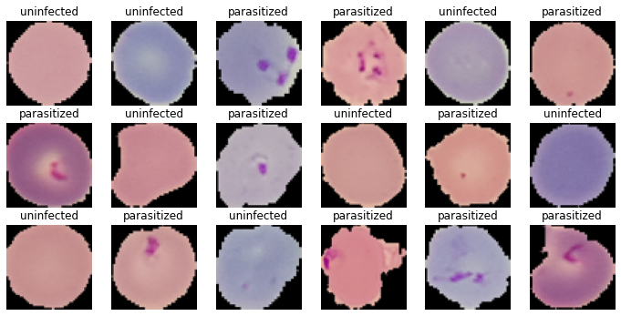

```python
# Visualizing a random set of the images

np.random.seed(42)
plt.figure(1 , figsize = (12 , 12))

for n in range(1, 19):
    plt.subplot(6, 6, n)
    index = int(np.random.randint(0, train_images.shape[0], 1))
    if train_labels[index] == 1:
        plt.title('parasitized')
    else:
        plt.title('uninfected')
    plt.imshow(train_images[index])
    plt.axis('off')
```

##### **Observations and insights:**

We can observe some clear differences between parastized blood cells and uninfected blood cells. In the parastized cells we can clearly see the parasitic circular portion of the cell due to the stain applied to the samples.

We can try to create an average parastized cell and uninfected cell and see if that provides any insights

### **Plotting the mean images for parasitized and uninfected**

```python
def find_mean_img(full_mat, title):
    mean_img = np.mean(full_mat, axis = 0)[0]
    plt.imshow(mean_img)
    plt.title(f'Average {title}')
    plt.axis('off')
    plt.show()
    return mean_img
```

**Mean image for parasitized**

```
Clipping input data to the valid range for imshow with RGB data ([0..1] for floats or [0..255] for integers).
```

[figure not shown]

```python
# If the label=1 then the image is parasitised and if the label=0 then the image is uninfected
parasitized_data=[]                                # Create a list to store the parasitized data
for img, label in zip(train_images, train_labels):
        if label==1:
              parasitized_data.append([img])

parasitized_mean = find_mean_img(np.array(parasitized_data), 'Parasitized')   # find the mean
```

**Mean image for uninfected**

```
Clipping input data to the valid range for imshow with RGB data ([0..1] for floats or [0..255] for integers).
```

[figure not shown]

```python
uninfected_data=[]
for img, label in zip(train_images, train_labels):
        if label==0:
              uninfected_data.append([img])

uninfected_mean = find_mean_img(np.array(uninfected_data), 'Uninfected')
```

##### **Observations and insights:**

We will want to convert the RGB color values to an HSV color value range so we can later run both data sets through our models to see which model performs better. HSV seperates out the intensity from the color value, and can sometimes help with image detection using machine learning models

### **Converting RGB to HSV of Images using OpenCV**

#### **Converting the train data**

```python
gfx=[]   # to hold the HSV image array
for i in np.arange(0,24958,1):
  a=cv2.cvtColor(train_images[i],cv2.COLOR_BGR2HSV)
  gfx.append(a)
gfx=np.array(gfx)
```

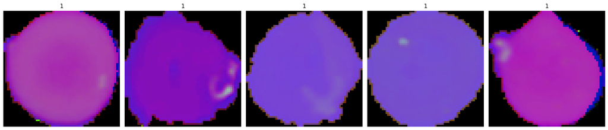

```python
viewimage=np.random.randint(1,100,5)
fig,ax=plt.subplots(1,5,figsize=(18,18))
for t,i in zip(range(5),viewimage):
  Title=train_labels[i]
  ax[t].set_title(Title)
  ax[t].imshow(gfx[i])
  ax[t].set_axis_off()
  fig.tight_layout()
```

#### **Converting the test data**

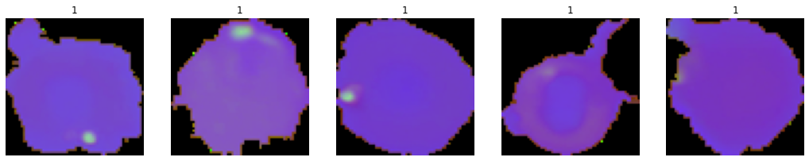

```python
# For the test set as well

gfxtest=[]
for i in np.arange(0,2600,1):
  atest=cv2.cvtColor(test_images[i],cv2.COLOR_BGR2HSV)
  gfxtest.append(atest)
gfxtest=np.array(gfxtest)

viewimage=np.random.randint(1,100,5)
fig,ax=plt.subplots(1,5,figsize=(18,18))
for t,i in zip(range(5),viewimage):
  Title=test_labels[i]
  ax[t].set_title(Title)
  ax[t].imshow(gfxtest[i])
  ax[t].set_axis_off()
```

##### **Observations and insights:**

The HSV images show clear color distinctions and may be useful when later running our models

We will also apply Gaussian Blurring to our images. Blurring the images can help improve image detection

### **Processing Images using Gaussian Blurring**

#### **Gaussian Blurring on train data**

```python
gbx=[]  ## to hold the blurred images
for i in np.arange(0,24958,1):
  b= cv2.GaussianBlur(train_images[i], (5, 5), 0)
  gbx.append(b)
gbx=np.array(gbx)
```

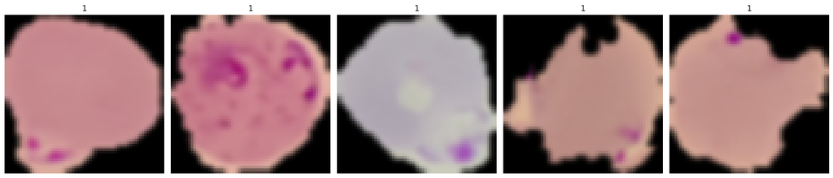

```python
viewimage=np.random.randint(1,100,5)
fig,ax=plt.subplots(1,5,figsize=(18,18))
for t,i in zip(range(5),viewimage):
  Title=train_labels[i]
  ax[t].set_title(Title)
  ax[t].imshow(gbx[i])
  ax[t].set_axis_off()
  fig.tight_layout()
```

#### **Gaussian Blurring on test data**

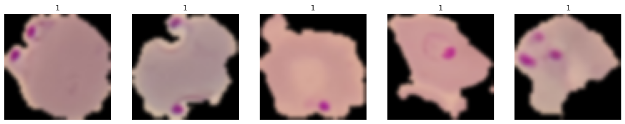

```python
gbxtest=[]
for i in np.arange(0,2600,1):
  b= cv2.GaussianBlur(test_images[i], (5, 5), 0)
  gbxtest.append(b)
gbxtest=np.array(gbxtest)

viewimage=np.random.randint(1,100,5)
fig,ax=plt.subplots(1,5,figsize=(18,18))
for t,i in zip(range(5),viewimage):
  Title=test_labels[i]
  ax[t].set_title(Title)
  ax[t].imshow(gbxtest[i])
  ax[t].set_axis_off()
```

##### Observations and insights:

Blurred images add noise to the data set and gives a machine learning model potentially new features to extract and distinguish

## **Proposed approach**

We will construct a Sequential Convolutional Neural Network (CNN) with multiple layers. We will experiment and iterate different models with Convolutional layers, pooling layers, ReLU layers, Fully connected layers, and Loss layers (dropout).

We will try multiple model constructions and hyper tune our parameters to optimize our model

When comparing the accuracy of our models we will measure both the overall accuracy of the model by calculating how often the model correctly identifies a sample as being Parasitized or Uninfected, and the model’s ability to more specifically correctly diagnose Parasitized samples (recall).

Considering that the potential health consequences of failing to diagnose a Parasitized patient are far greater than the costs of incorrectly diagnosing an uninfected patient as Prarastizied, we will seek to construct a model correctly diagnoses Parastized samples

### One Hot Encoding on the train and test labels

```python
# Encoding Train Labels
train_labels=to_categorical(train_labels,2)
# Similarly let us try to encode test labels
test_labels=to_categorical(test_labels,2)
```

### **Normalize the images**

```python
# Normalizing the RGB values so each pixel has a value between 0 and 1

train_images = (train_images/255).astype('float32')
test_images = (test_images/255).astype('float32')
```

```python
# Checking to see if Mix Max values properly set

print("Train images minimum value", train_images.min())
print("Train images maximum value", train_images.max())
print("Test images minimum value", test_images.min())
print("Test images maximum value", test_images.max())
```

```
Train images minimum value 0.0
Train images maximum value 1.0
Test images minimum value 0.0
Test images maximum value 1.0
```

```python
# First we ensure our backend is cleared and we fix our seed for the random number generators so that we can receive the same outputu everytime

reset_random_seeds
```

```
<function __main__.reset_random_seeds>
```

## Base Model

Note: The Base Model has been fully built and evaluated with all outputs shown to give an idea about the process of the creation and evaluation of the performance of a CNN architecture. A similar process can be followed in iterating to build better-performing CNN architectures.

```python
#creating sequential model
model=Sequential()
model.add(Conv2D(filters=32,kernel_size=2,padding="same",activation="relu",input_shape=(64,64,3)))
model.add(MaxPooling2D(pool_size=2))
model.add(Dropout(0.2))
model.add(Conv2D(filters=32,kernel_size=2,padding="same",activation="relu"))
model.add(MaxPooling2D(pool_size=2))
model.add(Dropout(0.2))
model.add(Conv2D(filters=32,kernel_size=2,padding="same",activation="relu"))
model.add(MaxPooling2D(pool_size=2))
model.add(Dropout(0.2))
model.add(Flatten())
model.add(Dense(512,activation="relu"))
model.add(Dropout(0.4))
model.add(Dense(2,activation="softmax"))
model.summary()
```

```
Model: "sequential"
_________________________________________________________________
 Layer (type)                Output Shape              Param #
=================================================================
 conv2d (Conv2D)             (None, 64, 64, 32)        416

 max_pooling2d (MaxPooling2D  (None, 32, 32, 32)       0
 )

 dropout (Dropout)           (None, 32, 32, 32)        0

 conv2d_1 (Conv2D)           (None, 32, 32, 32)        4128

 max_pooling2d_1 (MaxPooling  (None, 16, 16, 32)       0
 2D)

 dropout_1 (Dropout)         (None, 16, 16, 32)        0

 conv2d_2 (Conv2D)           (None, 16, 16, 32)        4128

 max_pooling2d_2 (MaxPooling  (None, 8, 8, 32)         0
 2D)

 dropout_2 (Dropout)         (None, 8, 8, 32)          0

 flatten (Flatten)           (None, 2048)              0

 dense (Dense)               (None, 512)               1049088

 dropout_3 (Dropout)         (None, 512)               0

 dense_1 (Dense)             (None, 2)                 1026

=================================================================
Total params: 1,058,786
Trainable params: 1,058,786
Non-trainable params: 0
_________________________________________________________________
```

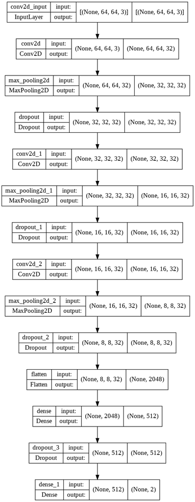

```python
## Visualizing the model

plot_model(model, to_file='model_plotBase.png', show_shapes=True, show_layer_names=True)
```

```python
# Compiling the model

model.compile(loss='binary_crossentropy', optimizer='adam', metrics=['accuracy'])
```

```python
# Using Callbacks to prevent model over fitting and improve processing times

callbacks = [EarlyStopping(monitor='val_loss', patience=2),
             ModelCheckpoint('.mdl_wts.hdf5', monitor='val_loss', save_best_only=True)]
```

```python
# Fitting and training our model using a batch size of 32

history=model.fit(train_images,train_labels,batch_size=32,callbacks=callbacks,validation_split=0.2,epochs=20,verbose=1)
```

# Evaluating the model on test data

```python
accuracy = model.evaluate(test_images, test_labels, verbose=1)
print('\n', 'Test_Accuracy:-', accuracy[1])
```

```
 Test_Accuracy:- 0.9830769300460815
```

# Plotting the confusion matrix

```
              precision    recall  f1-score   support

           0       0.98      0.99      0.98      1300
           1       0.99      0.97      0.98      1300

    accuracy                           0.98      2600
   macro avg       0.98      0.98      0.98      2600
weighted avg       0.98      0.98      0.98      2600
```

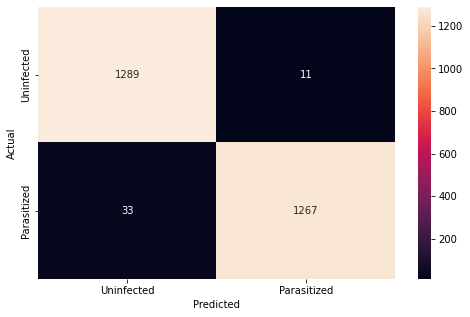

```python
pred = model.predict(test_images)
pred = np.argmax(pred,axis = 1)
y_true = np.argmax(test_labels,axis = 1)

#Printing the classification report
print(classification_report(y_true,pred))

#Plotting the heatmap using confusion matrix
cm = confusion_matrix(y_true,pred)
plt.figure(figsize=(8,5))
sns.heatmap(cm, annot=True,  fmt='.0f', xticklabels=['Uninfected', 'Parasitized'], yticklabels=['Uninfected', 'Parasitized'])
plt.ylabel('Actual')
plt.xlabel('Predicted')
plt.show()
```

## Plotting the train and validation curves

```python
# function to plot train and validation accuracy
def plot_accuracy(history):
    N = len(history.history["accuracy"])
    plt.figure(figsize=(7,7))
    plt.plot(np.arange(0, N), history.history["accuracy"], label="train_accuracy", ls='--')
    plt.plot(np.arange(0, N), history.history["val_accuracy"], label="val_accuracy", ls='--')
    plt.title("Accuracy vs Epoch")
    plt.xlabel("Epochs")
    plt.ylabel("Accuracy")
    plt.legend(loc="upper left")
```

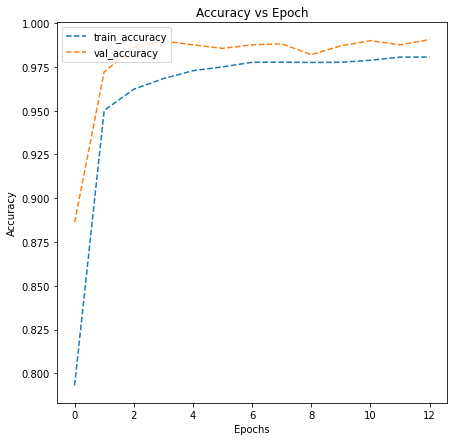

```python
plot_accuracy(history)
```

Here we can clearly observe that the training and valiation accuracy are increasing

And we can also notice that validation accuracy is slightly higher than the train accuracy

So now let's try to build another model with few more add on layers and try to check if we can try to improve the model. Therefore try to build a model by adding few layers if required and altering the activation functions.

# Model 1

Trying to improve the performance of our model by adding new layers

```python
# Clearing the backed and setting the random seed


reset_random_seeds
```

```
<function __main__.reset_random_seeds>
```

# Building the Model

```python
#Creating sequential model

model1=Sequential()
model1.add(Conv2D(filters=32,kernel_size=2,padding="same",activation="relu",input_shape=(64,64,3)))
model1.add(Activation('relu'))
model1.add(MaxPooling2D(pool_size=2))
model1.add(Dropout(0.2))
model1.add(Conv2D(filters=32,kernel_size=2,padding="same",activation="relu"))
model1.add(Activation('relu'))
model1.add(MaxPooling2D(pool_size=2))
model1.add(Dropout(0.2))
model1.add(Conv2D(filters=32,kernel_size=2,padding="same",activation="relu"))
model1.add(Activation('relu'))
model1.add(MaxPooling2D(pool_size=2))
model1.add(Dropout(0.2))
model1.add(Flatten())
model1.add(Dense(512,activation="relu"))
model1.add(Dropout(0.4))
model1.add(Dense(2,activation="softmax"))
model1.summary()
```

```
Model: "sequential_1"
_________________________________________________________________
 Layer (type)                Output Shape              Param #
=================================================================
 conv2d_3 (Conv2D)           (None, 64, 64, 32)        416

 activation (Activation)     (None, 64, 64, 32)        0

 max_pooling2d_3 (MaxPooling  (None, 32, 32, 32)       0
 2D)

 dropout_4 (Dropout)         (None, 32, 32, 32)        0

 conv2d_4 (Conv2D)           (None, 32, 32, 32)        4128

 activation_1 (Activation)   (None, 32, 32, 32)        0

 max_pooling2d_4 (MaxPooling  (None, 16, 16, 32)       0
 2D)

 dropout_5 (Dropout)         (None, 16, 16, 32)        0

 conv2d_5 (Conv2D)           (None, 16, 16, 32)        4128

 activation_2 (Activation)   (None, 16, 16, 32)        0

 max_pooling2d_5 (MaxPooling  (None, 8, 8, 32)         0
 2D)

 dropout_6 (Dropout)         (None, 8, 8, 32)          0

 flatten_1 (Flatten)         (None, 2048)              0

 dense_2 (Dense)             (None, 512)               1049088

 dropout_7 (Dropout)         (None, 512)               0

 dense_3 (Dense)             (None, 2)                 1026

=================================================================
Total params: 1,058,786
Trainable params: 1,058,786
Non-trainable params: 0
_________________________________________________________________
```

```python
# Compililng the Model
model1.compile(loss = 'binary_crossentropy',
                  optimizer = tf.keras.optimizers.Adam(learning_rate = 0.001),
                  metrics = ['accuracy'])
```

```python
# Using Callbacks

callbacks = [EarlyStopping(monitor='val_loss', patience=2),
             ModelCheckpoint('.mdl_wts.hdf5', monitor='val_loss', save_best_only=True)]
```

```python
# Fit and Train the Model

history1=model1.fit(train_images,train_labels,batch_size=32, callbacks= callbacks, validation_split=0.2,epochs=20,verbose=1)
```

```python
# Evaluating Model accuracy on the test set

accuracy1 = model1.evaluate(test_images, test_labels, verbose=1)
print('\n', 'Test_Accuracy:-', accuracy1[1])
```

```
 Test_Accuracy:- 0.9776923060417175
```

```
              precision    recall  f1-score   support

           0       0.97      0.99      0.98      1300
           1       0.99      0.97      0.98      1300

    accuracy                           0.98      2600
   macro avg       0.98      0.98      0.98      2600
weighted avg       0.98      0.98      0.98      2600
```

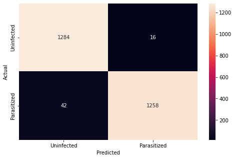

```python
# Plotting the confusion matrix

pred1 = model1.predict(test_images)
pred1 = np.argmax(pred1,axis = 1)
y_true = np.argmax(test_labels,axis = 1)

#Printing the classification report
print(classification_report(y_true, pred1))

#Plotting the heatmap using confusion matrix

cm = confusion_matrix(y_true, pred1)
plt.figure(figsize=(8,5))
sns.heatmap(cm, annot=True,  fmt='.0f', xticklabels=['Uninfected', 'Parasitized'], yticklabels=['Uninfected', 'Parasitized'])
plt.ylabel('Actual')
plt.xlabel('Predicted')
plt.show()
```

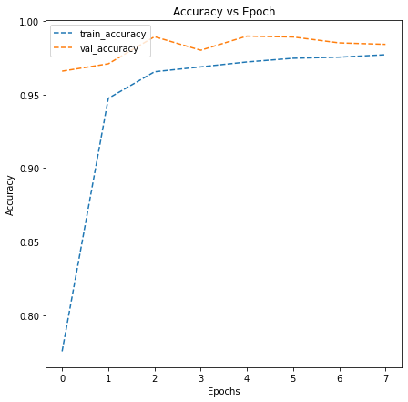

```python
# Plotting the Train and validation curves

plot_accuracy(history1)
```